# Lab 04 - La Quinta is Spanish for next to Denny’s, Pt. 2

Rosalina Delwiche

19 October 2022

The purpose of this analysis is to determine whether Mitch Herdbergs joke of whether LaQuinta means next to Deny’s holds true. To do so, we consider several states and analyze the minimum distance from each location in the state.

### Load packages and data

```r
library(tidyverse)
library(dsbox)
```

### Read state data

```r
states <- read_csv("data_raw/states.csv")
```

### Dennys in AK

Filtering the Denny’s dataframe for Alaska (AK) and saving the result as dn_ak

```r
dn_ak <- dennys %>% filter(state == "AK")
nrow(dn_ak)
```

```
## [1] 3
```

### LaQuinta in AK

Filtering the La Quinta dataframe for Alaska (AK) and saving the result as lq_ak

```r
lq_ak <- laquinta %>% filter(state == "AK")
nrow(lq_ak)
```

```
## [1] 2
```

### Pairings and Joining

Next, we see how many pairings there are between all Denny’s and all La Quinta locations in Alaska, i.e. how many distances do we need to calculate between the locations of these establishments in Alaska?

```r
dn_lq_ak <- full_join(dn_ak, lq_ak, by = "state")

dn_lq_ak
```

```
## # A tibble: 6 × 11
##   address.x      city.x state zip.x longi…¹ latit…² addre…³ city.y zip.y longi…⁴
##   <chr>          <chr>  <chr> <chr>   <dbl>   <dbl> <chr>   <chr>  <chr>   <dbl>
## 1 2900 Denali    Ancho… AK    99503   -150.    61.2 3501 M… "\nAn… 99503   -150.
## 2 2900 Denali    Ancho… AK    99503   -150.    61.2 4920 D… "\nFa… 99709   -148.
## 3 3850 Debarr R… Ancho… AK    99508   -150.    61.2 3501 M… "\nAn… 99503   -150.
## 4 3850 Debarr R… Ancho… AK    99508   -150.    61.2 4920 D… "\nFa… 99709   -148.
## 5 1929 Airport … Fairb… AK    99701   -148.    64.8 3501 M… "\nAn… 99503   -150.
## 6 1929 Airport … Fairb… AK    99701   -148.    64.8 4920 D… "\nFa… 99709   -148.
## # … with 1 more variable: latitude.y <dbl>, and abbreviated variable names
## #   ¹longitude.x, ²latitude.x, ³address.y, ⁴longitude.y
```

There are 3 Denny’s locations in Alaska and 2 LaQuinta locations in Alaska. dn_la_ak restructures the data to pair these locations. As we can see there are 6 rows with the variables with columns relating to the addresses when we perform the full join. The columns include the address, city, longitutude, latitude, and state, with two occurences per each since there is one for a dennys and one for a laquinta.

…

### Haversine Function

To calculate the distance between any two points on the earth, we use the Haversine distance formula. This formula takes into account the fact that the earth is not flat, but instead spherical.

This function takes five arguments: * Longitude and latitude of the first location * Longitude and latitude of the second location * A parameter by which to round the responses

```r
haversine <- function(long1, lat1, long2, lat2, round = 3) {
  # convert to radians
  long1 = long1 * pi / 180
  lat1  = lat1  * pi / 180
  long2 = long2 * pi / 180
  lat2  = lat2  * pi / 180
  R = 6371 # Earth mean radius in km
  a = sin((lat2 - lat1)/2)^2 + cos(lat1) * cos(lat2) * sin((long2 - long1)/2)^2
  d = R * 2 * asin(sqrt(a))
  return( round(d,round) ) # distance in km
}
```

### Calculate the Distances

We calculate the distances between all pairs of Denny’s and La Quinta locations and save this variable as distance. We save this variable in the dn_lq_ak data frame so that you can use it later.

```r
dn_lq_ak <- dn_lq_ak %>% mutate(distance_km = haversine(longitude.x, latitude.x, longitude.y, latitude.y))
```

### Minimum Distance

We calculate the minimum distance between a Denny’s and La Quinta for each Denny’s location. To do so we group by Denny’s locations and calculate a new variable that stores the information for the minimum distance

```r
dn_lq_ak_mindist <- dn_lq_ak %>%
  group_by(address.x) %>%
  summarise(closest = min(distance_km))
```

### Distribution of the distances Denny’s and the nearest La Quinta locations in Alaska

To describe the distribution of the distances Denny’s and the nearest La Quinta location, we make a dsataset with the closest distances.

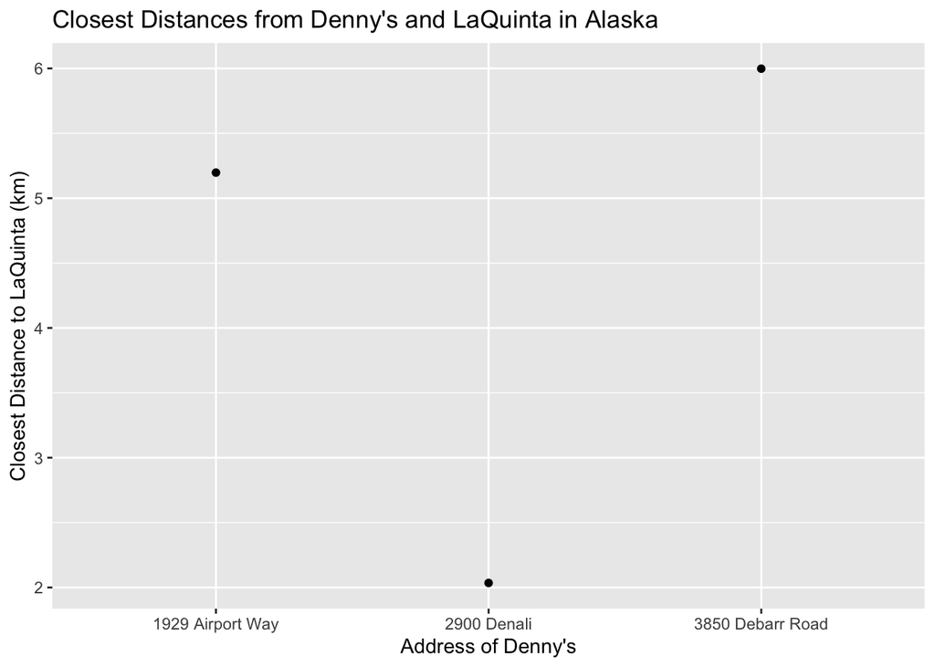

```r
dn_lq_ak_mindist %>% ggplot(aes(x=address.x, y=closest)) +
  geom_point() +
  ggtitle("Closest Distances from Denny's and LaQuinta in Alaska")+
  xlab("Address of Denny's")+
  ylab("Closest Distance to LaQuinta (km)")
```

### North Carolina Denny’s and LaQuinta

We repeate the same analysis for North Carolina. We follow the following procedure-

1. filter Denny’s and La Quinta Data Frames for NC
2. join these data frames to get a completelist of all possible pairings
3. calculate the distances between all possible pairings of Denny’s and La Quinta in NC
4. find the minimum distance between each Denny’s and La Quinta location
5. visualize and describe the distribution of these shortest distances using appropriate summary statistics.

Below is steps i through iv

```r
dn_nc <- dennys %>% filter(state == "NC")
lq_nc <- laquinta %>% filter(state == "NC")
dn_lq_nc <- full_join(dn_nc, lq_nc, by = "state")

dn_lq_nc <- dn_lq_nc %>% mutate(distance_km = haversine(longitude.x, latitude.x, longitude.y, latitude.y))
dn_lq_nc_mindist <- dn_lq_nc %>%
  group_by(address.x) %>%
  summarise(closest = min(distance_km))
```

Lastly we create the visualization for v.

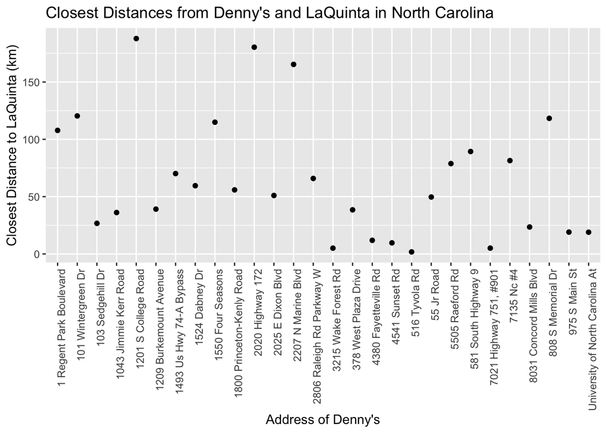

```r
dn_lq_nc_mindist %>% ggplot(aes(x=address.x, y=closest)) + geom_point()+ theme(axis.text.x = element_text(angle=90, hjust=1)) +
  ggtitle("Closest Distances from Denny's and LaQuinta in North Carolina")+
  xlab("Address of Denny's")+
  ylab("Closest Distance to LaQuinta (km)")
```

…

### Texas Denny’s and LaQuinta

Once again, we repeat this same process for texas.

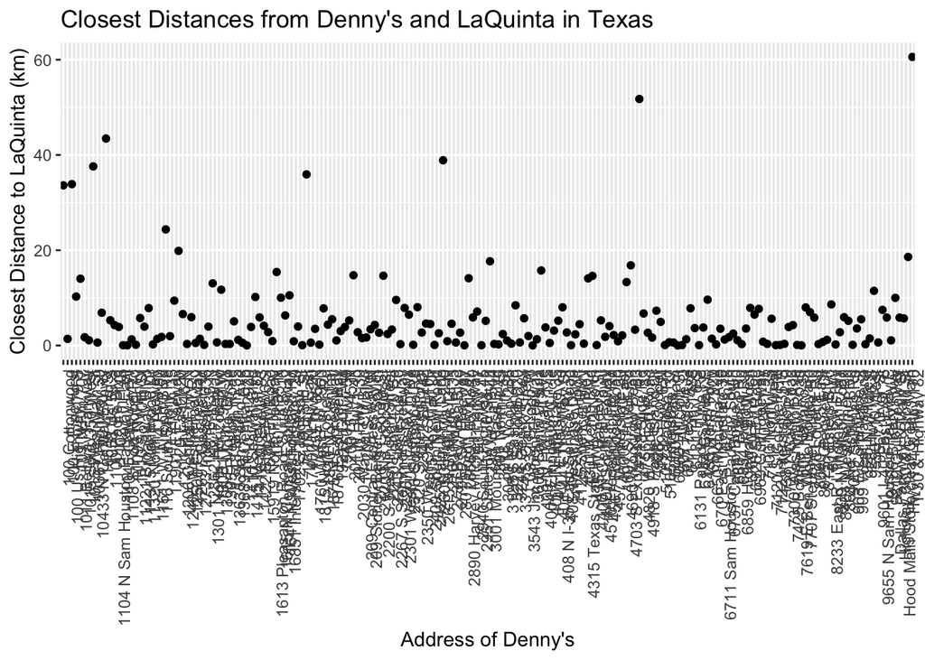

```r
dn_tx <- dennys %>% filter(state == "TX")
lq_tx <- laquinta %>% filter(state == "TX")
dn_lq_tx <- full_join(dn_tx, lq_tx, by = "state")

dn_lq_tx <- dn_lq_tx %>%
  mutate(distance_km = haversine(longitude.x, latitude.x, longitude.y, latitude.y))

dn_lq_tx_mindist <- dn_lq_tx %>%
  group_by(address.x) %>%
  summarise(closest = min(distance_km))

dn_lq_tx_mindist %>% ggplot(aes(x=address.x, y=closest)) +
  geom_point()+
  theme(axis.text.x = element_text(angle=90, hjust=1)) +
  ggtitle("Closest Distances from Denny's and LaQuinta in Texas")+
  xlab("Address of Denny's")+
  ylab("Closest Distance to LaQuinta (km)")
```

…

### Maryland Denny’s and LaQuinta

We repeat this proccess once again for another state, following the same steps. The state chosen is Maryland.

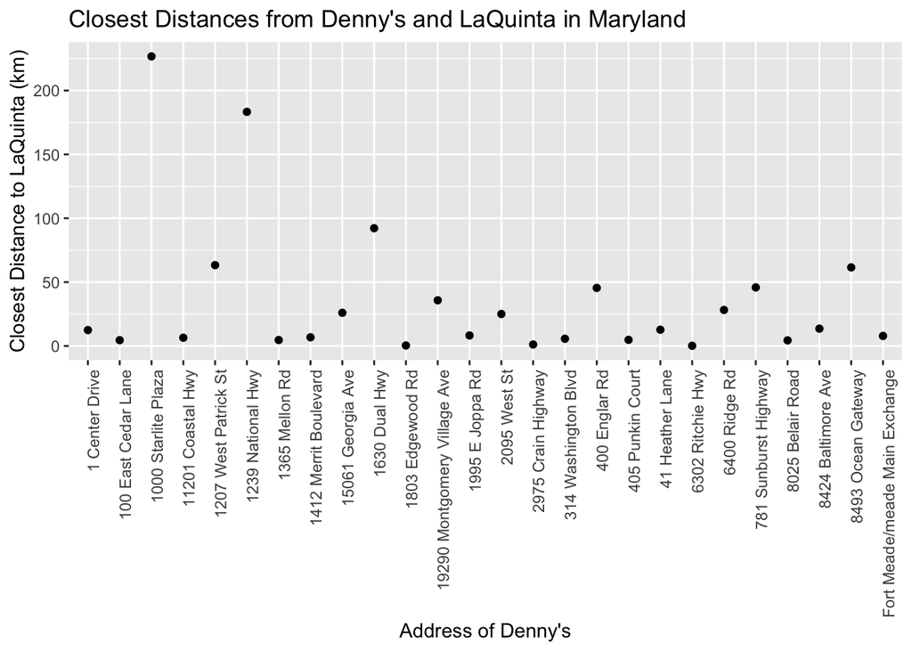

```r
dn_md <- dennys %>% filter(state == "MD")

lq_md <- laquinta %>% filter(state == "MD")

dn_lq_md <- full_join(dn_md, lq_md, by = "state")

dn_lq_md <- dn_lq_md %>% mutate(distance_km = haversine(longitude.x, latitude.x, longitude.y, latitude.y))

dn_lq_md_mindist <- dn_lq_md %>%
  group_by(address.x) %>%
  summarise(closest = min(distance_km))

dn_lq_md_mindist %>% ggplot(aes(x=address.x, y=closest)) +
  geom_point()+
  theme(axis.text.x = element_text(angle=90, hjust=1)) +
  ggtitle("Closest Distances from Denny's and LaQuinta in Maryland")+
  xlab("Address of Denny's")+
  ylab("Closest Distance to LaQuinta (km)")
```

```r
dn_lq_md_mindist %>% filter(closest <= 1)
```

```
## # A tibble: 2 × 2
##   address.x        closest
##   <chr>              <dbl>
## 1 1803 Edgewood Rd   0.382
## 2 6302 Ritchie Hwy   0.147
```

…

### Conclusion

Out of the four states we analyzed - Alaska, North Carolina, Texas, and Maryland the Mitch Hedbergs joke does not apply. In these states it is not uncommon for there to be a LaQuinta’s well over 5 km from Denny’s. The answer to the question is dependent on how we define “close to”.

```r
dn_lq_ak_median <- median(dn_lq_ak_mindist$closest)
dn_lq_tx_median <- median(dn_lq_tx_mindist$closest)
dn_lq_nc_median <- median(dn_lq_nc_mindist$closest)
dn_lq_nc_median <- median(dn_lq_md_mindist$closest)

dn_lq_ak_median
```

```
## [1] 5.197
```

```r
dn_lq_tx_median
```

```
## [1] 3.3715
```

```r
dn_lq_nc_median
```

```
## [1] 12.5715
```

```r
dn_lq_nc_median
```

```
## [1] 12.5715
```

Perhaps closeness is dependent on individuals. Maybe for Mitch this is considered close.